# Ncala.Regression.Report3

Xolani

2025-05-26

# Master of Arts in E-Science

## Statistical Computing and Inference for the Social Sciences and Humanities

### (SOSS 7098) Research Report 3: Regression and Causal Analysis

### **Political Stability and Public Trust in the Police**

**University of Witswatersrand**

**Student: Xolani Charles Ncala (2456543)**

> *I know plagiarism is wrong; I have read the section in the Essay Writing Guide concerning plagiarism; and I declare that this Essay is my own work.*

# Introduction

In many African states, trust in public institutions, particularly the police or law enforcement agencies, remains fragile and is deeply influenced by the nation’s broader political environment. Multiple studies have highlighted that political instability, whether through coups, electoral violence, civil unrest, or state repression, often undermines the perceived legitimacy of law enforcement agencies (Fagbemi & Fajingbesi, 2022; Morris, 2015; Gaberli et al., 2022). When citizens experience or anticipate political violence, they may begin to view the police not as neutral enforcers of law and order but as instruments of partisan interests or authoritarian control. This erosion of trust can weaken democratic accountability, increase social fragmentation, and reduce public cooperation with security institutions. Therefore, understanding the relationship between political stability and public trust in the police is not just an academic exercise but a vital step toward improving governance and state-society relations in Africa.

This report examines the impact of political stability, as measured by the World Governance Indicators Index for Political Stability and Absence of Violence (PV), on public trust in the police, as reported by the Ibrahim Index of African Governance (IIAG). The relevance of this topic is amplified by recent democratic backsliding and citizen-led protests in countries such as Nigeria, Rwanda, and Sudan, where the role of the police is increasingly being contested. Using a cross-national approach, this study sets out to test whether more politically stable countries enjoy a greater level of trust in police or law enforcement. The report begins with outlining the theoretical relationship between political stability and public confidence in policing, followed by a section on the methodology and measurement of the key variables used in the study. Then, third section of the paper provides univariate and bivariate analyses of the key measures, and the last section interprets the results and their potentially significant implications for governance in African contexts.

# Political Stability, Violence, and Terrorism

Prominent development scholars who have discussed the multidimensional concept of political stability violence and terrorism include Yagmur Garbeli, Umit Garbeli, and Mehmet Guler (2022) in their article “Impact of Political Stability and Absence of Violence/ Terrorism on Tourism,” where they were concerned with investigating whether political stability and the absence of violence or terrorism has a positive significant effect on tourism flows across 137 countries for 13 years. Garbeli et al. (2022) used tourism statistics, including the percentage change in visitor arrivals and the Worldwide Governance Indicators, to measure political stability and the absence of violence or terrorism. Their findings confirmed that higher levels of the latter are associated with increased long-term tourist arrivals. According to their paper, political stability is “the absence or a low level of death because of political violence, military coup, the violence of groups in the society or revolt in the country” (Garbeli et al., 2022).

Although Garbeli et al. (2022) definition is correct, the Worldwide Governance Indicators (2022) provide a more precise definition of political stability as:

> *“Political stability and the absence of violence measures perceptions of the likelihood that the government will be destabilized or overthrown by unconstitutional or violent means, including politically motivated violence and terrorism.”*

As defined, terrorism is a significant factor that can potentially threaten a country’s political stability. According to Garbeli et al. (2022), terrorism involves movements, actions, and behaviours that are aimed at imposing specific ideas or frightening populations, which can lead to destabilization and violence within a country. Since political stability is characterized by low levels of violence and the absence of threats to governmental authority, it shows that terrorism directly undermines this stability when it increases insecurity, creates uncertainty, and potentially incites political unrest or upheavals. Therefore, terrorism negatively impacts political stability by fostering an environment of insecurity and disorder, which can threaten the legitimacy and functioning of political institutions.

In an article by Fagbemi & Fajingbesi (2022), the authors conceptualize political stability primarily as the public’s perception of the durability and resilience of the political system within a country, arguing that “it reflects the degree to which a government can maintain order, legitimacy, and effective functioning without succumbing to violence or unrest.” They claim that the complex relationship between socioeconomic factors and political stability, while emphasizing how issues such as high unemployment, income inequality, and inadequate living standards can give rise to threats to the state’s political stability. Fagbemi & Fajingbesi (2022) also highlight those stronger economic conditions often help promote political stability by creating jobs, expanding opportunities, and easing social tensions. Meanwhile, the quality of governance plays a critical role, as institutions that tend to be transparent and accountable are more likely to earn public trust, unlike when they are weak and corrupt (Fagbemi & Fajingbesi 2022). This is especially true for places with a history of unrest where distrust can grow and the risk of renewed instability increases. The main idea to capture is that political stability is not just the absence of violence, but it is a condition that depends on the strength of the country’s institutions, how well the government works, and the overall social and economic conditions. These factors help us understand how political stability can influence how much the public trusts the police.

# Public Trust in Police

Trust in the police plays a vital role in shaping the effectiveness, legitimacy, and social acceptance of law enforcement institutions. According Boateng (2012) when the community perceives the police as trustworthy, they become more inclined to cooperate with the enforcement officers, to abide by the laws and tend to participate in crime prevention efforts. This cooperation is essential for the maintenance of social order and ensuring that police operations in the community run smoothly. Conversely when the public lacks trust in the police or law enforcement, they are “often suspicious, hostile, and non-compliant” to processes related to law enforcement (Boateng, 2012). As a result, this obstructs the progress of enforcement and undermines social stability.As Goldsmith (2005) emphasizes that “trust is linked to the capacity of state police to provide basic citizen security”, it is significant because when the society trusts their police, they view them as legitimate authorities acting in the public’s best interests. This relationship is crucial as it simply underpins the police’s ability to enforce laws effectively and fairly, because without trust the police’s efforts can be met with resistance, therefore making it difficult to achieve law and order.

Both authors Goldsmith (2005) and Boateng (2012) mention two key theories that properly explain trust in the police. The first theory is motive-based trust, which typically develops when citizens perceive police actions as motivated by good intentions and fairness. Simply, it maintains that public trust is related to how the police use their authority to serve the best interests of society (Boateng, 2012). The second theory is institutional trust, which refers to confidence in the police as an organization, encompassing perceptions of their competence, integrity, and responsibility. As Goldsmith (2012) states it is the “belief that this collective entity… fulfills its obligations and acts responsibly.” Both forms of trust theories essentially promote cooperation, legitimacy, and societal stability. This underscores the crucial role of the public in supporting law enforcement through their trust and cooperation.

For the examination set out in this paper, the conceptualization of trust adopted defines it as “a set of beliefs or expectations rather than a purely affective reaction” (Boateng, 2012). This definition highlights that trust is grounded in cognitive assessments based on past experiences, perceptions of competence, honesty, and the intentions of the police. It is not merely a feeling but a reasonable judgment about whether the police are reliable and act in the community’s best interests.

# Linking Political Stability and Public Trust in Police

Political stability plays a fundamental role in shaping citizens’ perceptions of various state institutions, including the police. Authors like Garbeli et al. (2022) have argued that political stability does not only reflect the absence of armed conflict but also reflects the government’s ability to prevent unrest in the country, its role to uphold law and order, and its capacity to maintain institutional legitimacy. Fagbemi and Fajingbesi (2022) expand this view further, therefore arguing that political stability is deeply intertwined with “social and economic conditions, institutional strength, and public perceptions of government performance.” In countries with an unstable or violent context, the police institution tends to become entangled in the state’s coercive responses to rising internal dissent, which can possibly erode its image as a neutral and accountable actor in society.

This becomes particularly important when considering the level of trust the public has in the police. As Boateng (2012) and Goldsmith (2005) have suggested, trust in the police typically hinges not only on perceptions of fairness and moral intention (motive-based trust) but also on broader institutional factors associated with it, such as police competence, integrity, and transparency (institutional trust). Countries that have politically unstable environments and are usually marked by events of terrorism or increasing arbitrary state repression will typically have police that may be perceived as aligned with authoritarian interests or perceived as incapable of protecting the public (Goldsmith, 2005). This means that their failure to prevent violence, or their direct involvement in the state’s suppressive tactics, has the effect of undermining both motive-based and institutional trust. So, when a country faces political instability because of violence, terrorism, or signs of weak governance, its people will often start to lose confidence in law enforcement. This means that the perception of the police as a fair and neutral authority diminishes as people begin to associate the police force with government failure, arbitrary abuse of power, or even corruption. On the other hand, in countries where there is higher political stability and the government is seen as functioning correctly, the citizens are more likely to trust the police and believe that they are working in the public’s best interests. This study hypothesizes that higher levels of political stability are positively associated with increased public trust in the police across African countries.

**H1:** Higher levels of Political Stability and Absence of Violence/ Terrorism are positively associated with increased Public Trust in the Police.  
**H0:** There is no statistically significant relationship between Political Stability and Absence of Violence/ Terrorism and Public Trust in the Police.

# The Concepts of Measurements and Control Variables

In this research, the independent variable (X) is Political Stability and Absence of Violence/Terrorism, which is assessed through the data from the Worldwide Governance Indicators (WGI) 2022 for 36 African countries [n=36]. The WGI measure this indicator on a continuous scale ranging from approximately [-2.5 (weak stability) to + 2.5 (strong stability)] (Kaufman & Kraay, 2024. The dependent variable (Y) is Public Trust in the Police, which is measured using 2022 data from the Ibrahim Index of African Governance (IIAG) with the same number of observations from African countries [n=36]. IIAG measure this indicator on a continuous scale from [0 (no trust at all) to 100 (highest levels of trust)] (IIAG, 2024). The above formulated causal hypothesis (H1) posits that higher levels of political stability and the absence of violence or terrorism are positively correlated with increased public trust in law enforcement. It is also underpinned by the robust theoretical considerations suggesting that the political stability of a nation bolsters the legitimacy and effective functioning of state institutions, including the police (Boateng 2012).

In stable political environments, citizens are less likely to perceive the police as tools of repression or partisan control and more likely to regard them as impartial enforcement authority. In terms of the data sources the WGI data, a project of the World Bank, provides a comprehensive and internationally validated measure of political stability which “draws on multiple expert assessments and survey data” to enhance the reliability and validity of this indicator (Kaufman & Kraay, 2024). The measure of public trust in the police from the IIAG is derived from representative public survey data, which bolsters its credibility. According to Boateng (2012) challenges in the measurements may arise due to the subjective nature of trust perceptions and the variability of local policing experiences that can potentially impact the cross-country comparability. In this sense, it is certain the use of the mentioned data sources and the theoretically justified measures strengthens the overall reliability and validity of the use of these variables in the analysis.

With this background the study incorporates two control variables both sourced from the 2022 WGI data: the Rule of Law indicator (c1) measured on a continuous scale approximately from [-2.5 (low level of rule of law) to +2.5 (High level of rule of law), and GDP per capita (c2) which means Gross Domestic Product per person expressed in U.S dollars ($) (Kaufman & Kraay, 2024). These specific variables were chosen due to their theoretical and empirical relevance to both the independent and dependent variable, reflected in the previous theory and Concepts section. The Rule of Law indicator is considered to be causally prior to political stability because it encapsulates a nation’s laws that provide for the strength, fairness, and effectiveness of its legal institutions, which are significantly influential in the prevention of violence, terrorism and unwanted authoritarianism. According to Garbeli et al (2022) a nation with robust rules of law tends to foster greater accountability and transparency within its law enforcement agencies which can potentially increase the public’s trust in their work. On the economic spectrum, the measure of the GDP per capita serves as a vital measure of a nation’s economic health and prosperity, a factor that logically precedes and influences both independent and dependent variables. Usually, countries with higher GDP levels are more likely to maintain stable governance and possess better-funded professional police forces, which in turn receive greater public confidence for their effectiveness in maintaining law and order. From an analytical perspective, it is reasonable to hypothesize that nations with elevated GDP per capita and a well-established rule of law are more likely to demonstrate higher political stability and greater public trust in law enforcement institutions.

**Table 1** below, shows the preview and structure of the data including the country name, year, its score on the independent (X = PS.est) and (Y = PTP.est) variable, and the two controls (c1 = RL.est) and (c2 = GDP.est) from first 6 countries.The complete data Table with 36 countries titled Apendix 1 is presented at the end of the report.

Table 1: Preview of key varibales and controls

| Code | Country | Year | PS.est | PTP.est | RL.est | GDP.est ($) |
| --- | --- | --- | --- | --- | --- | --- |
| AGO | Angola | 2022 | -0.630 | 25.0 | -1.022 | 7397.486 |
| BEN | Benin | 2022 | -0.343 | 76.7 | -0.596 | 3588.335 |
| BFA | Burkina Faso | 2022 | -1.815 | 84.6 | -0.612 | 2466.053 |
| BWA | Botswana | 2022 | 1.074 | 44.9 | 0.459 | 18648.136 |
| CIV | Cote d’Ivoire | 2022 | -0.587 | 43.1 | -0.474 | 6261.533 |
| CMR | Cameroon | 2022 | -1.380 | 43.0 | -1.039 | 4843.650 |

# Univariate Analysis of Variables.

#### *A. Political Stability and Absence of Violence or Terrorrism.*

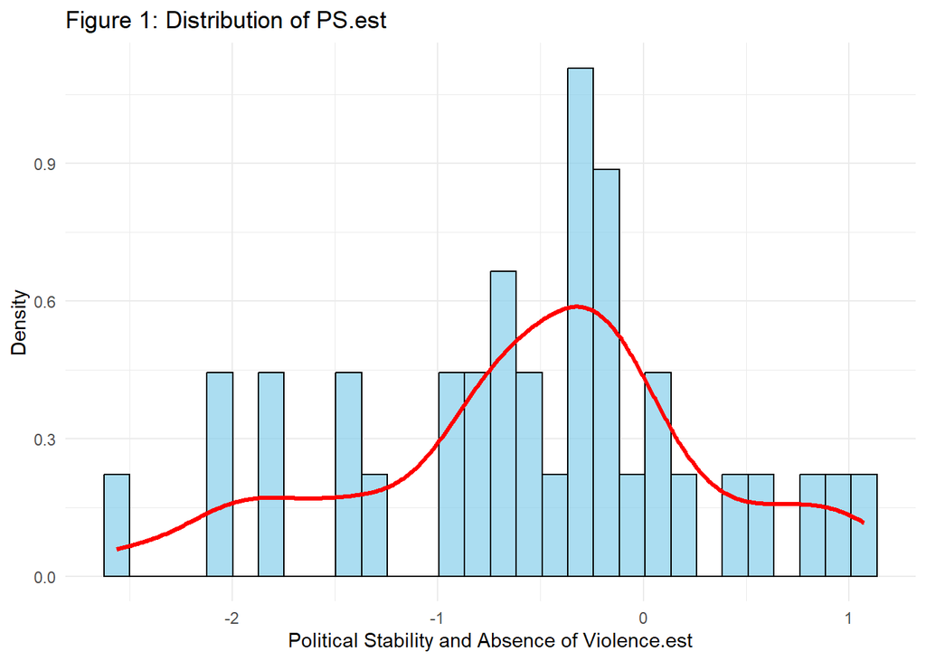

### *B. Public Trust in the Police.*

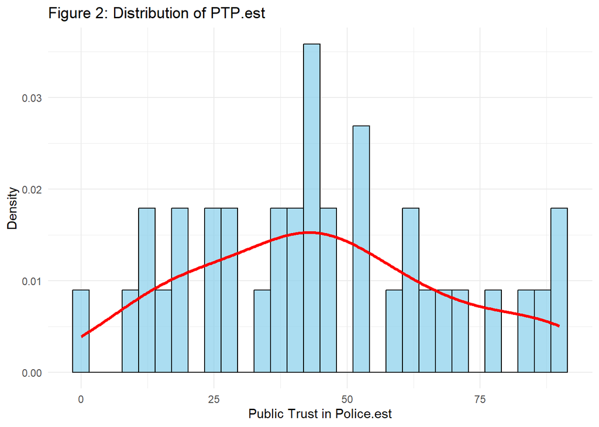

### *C. Rule of Law Indicator*

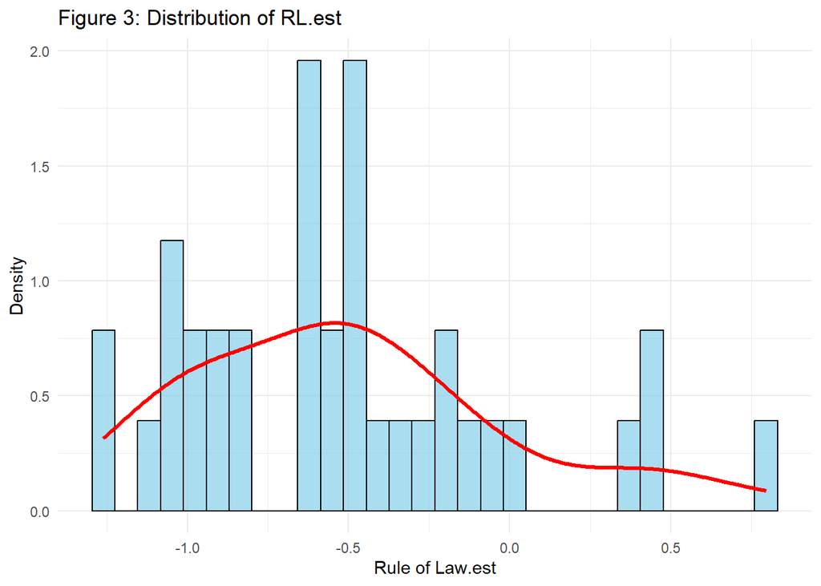

The histogram distributions for the above two variables Political Stability and Public Trust in Police, and a control measure which is the Rule of Law indicator show their own distinct patterns across the data of the 36 countries of focus. Figure 1 for Political Stability displays a bimodal and left-skewed distribution, which reflects a polarization where a subset of countries experiences relative peace and order, while others are characterized by the presence instability and violence, with a prevalence of fewer extreme cases at the lower end of the spectrum. Figure 2 for Public Trust in Police similarly demonstrates a weakly multimodal distribution that is slightly left skewed, therefore indicating the presence of distinct clusters, where many nations report moderate to high levels of trust, whereas a smaller proportion of nation exhibit low levels of trust which extends histogram tail to the lower end. Conversely, Figure 3 Rule of Law estimate histogram tends to follow a unimodal and right-skewed distribution, with most countries falling within the lower moderate ranges of legal institutional strength and only a limited number reaching very high levels.

There comes a difference when looking at Figure 4 below, the density histogram for the GDP per capita measure which is placed under the dollar currency. From the visuals of that graph it shows that it is clearly unimodal with a strong right-skew. According to Fagbemi & Fajingbesi (2022), the distribution of the measure of gross domestic product is often highly skewed, in this case it is because a few rich countries like Botswana have extremely high values compared to the poor ones liken Burkina Faso. To remedy this, they suggest a common practice among statisticians, which includes logging the financial value in dollars, so that the large values are compressed to force a normal distribution that is more symmetric and suitable for analysis (Fagbemi & Fajingbesi, 2022). As a result, I have logged all the values under the variable GDP.est ($) to produce a new variable called LogGDP.est with a logarithmic scale instead of the monetary units. Below Figure 4,is Figure 5 the univariate histogram for this variable.

### *D. Gross Domestic Product per capita*

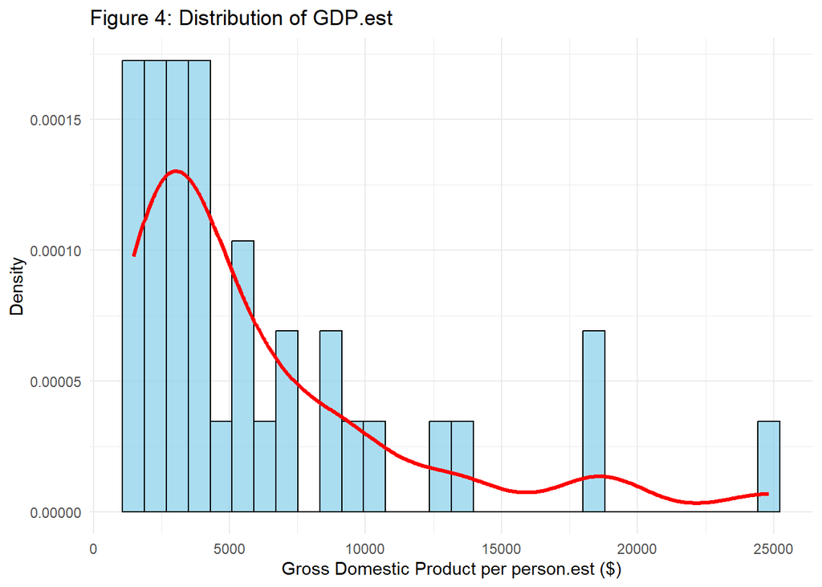

### *E. Log Domestic Product per capita*

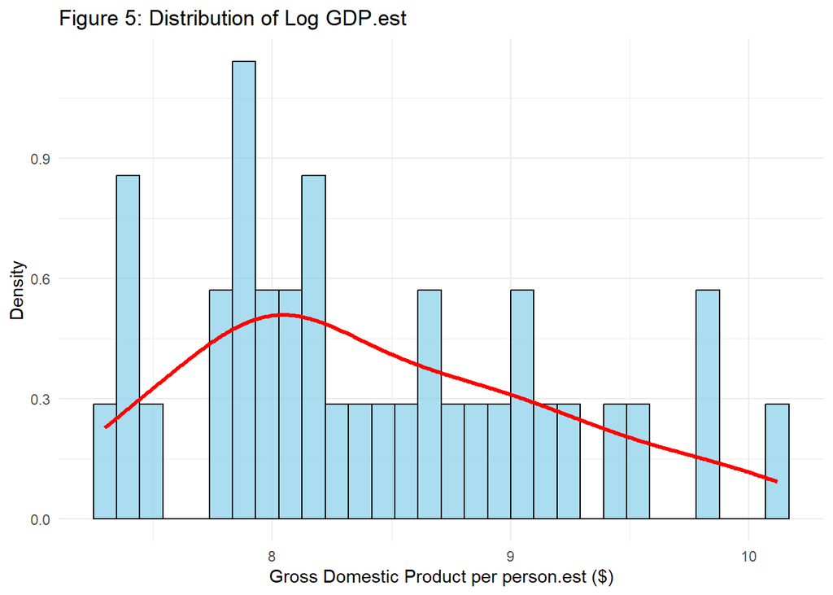

The new preview data with the added with the added LogGDP estimate column is displayed in Table 2 below and Appendix 1 at the end of the report presents the complete data table with all 36 countries. In this regard further bivariate analysis and regression analysis in this report will focus more on using the LogGDP values for the nation’s economic status instead of the base dollar GDP value.

Table 2: Preview of key varibales and controls + LogGDP

| Code | Country | Year | PS.est | PTP.est | RL.est | GDP.est ($) | LogGDP.est |
| --- | --- | --- | --- | --- | --- | --- | --- |
| AGO | Angola | 2022 | -0.630 | 25.0 | -1.022 | 7397.486 | 8.908895 |
| BEN | Benin | 2022 | -0.343 | 76.7 | -0.596 | 3588.335 | 8.185444 |
| BFA | Burkina Faso | 2022 | -1.815 | 84.6 | -0.612 | 2466.053 | 7.810374 |
| BWA | Botswana | 2022 | 1.074 | 44.9 | 0.459 | 18648.136 | 9.833502 |
| CIV | Cote d’Ivoire | 2022 | -0.587 | 43.1 | -0.474 | 6261.533 | 8.742180 |
| CMR | Cameroon | 2022 | -1.380 | 43.0 | -1.039 | 4843.650 | 8.485424 |

# Bivariate Analysis of the Variables

In this section the report runs some pre analysis of the study’s key variables and controls using a correlation matrix, to examine some the initial existing linear link between them, and to highlight any overlapping control variables due to multicollinearity which might distort the regression results. Its importance simply lies on the fact that it may help detect these issues that make coefficients misleading before running regressions. The correlation matrix that is presented in Table 3 examines the key variables under study: Political Stability and Absence of Violence/Terrorism (PS.est), Public Trust in the Police (PTP.est), Rule of Law (RL.est), and the natural logarithm of GDP per capita (LogGDP.est).

Table 3: Correlation matrix of the Variables and Controls

|  | PS.est | PTP.est | RL.est | LogGDP.est |
| --- | --- | --- | --- | --- |
| PS.est | 1.000 | -0.093 | 0.645 | 0.500 |
| PTP.est | -0.093 | 1.000 | 0.229 | -0.237 |
| RL.est | 0.645 | 0.229 | 1.000 | 0.586 |
| LogGDP.est | 0.500 | -0.237 | 0.586 | 1.000 |

The results reveal a moderate positive relationship between PS.est and RL.est (r = 0.645), indicating that nations with higher levels of political stability tend to also demonstrate stronger rule of law. Additionally, PS.est shows a moderate correlation with LogGDP.est (r = 0.500), suggesting that political stability is generally associated with greater economic development. The relationship between RL.est and LogGDP.est is similarly moderate (r = 0.586), implying that improvements in the rule of law tend to align with better economic performance.

On the contrary, the correlation between PS.est and PTP.est is weak and negative (r = -0.093), indicating a minimal and potentially non-significant linear relationship between political stability and public trust in the police within the sample. Similarly, the correlations between PTP.est and RL.est (r = 0.229) and between PTP.est and LogGDP.est (r = -0.237) are relatively low, implying that trust in law enforcement is only loosely related to institutional strength or economic indicators. In the broader scheme the correlation matrix does not show significantly string relationships between the variables, meaning that there is no immediate concern about the multicollinearity of variables and controls.

# The Effect decomposition of the Variables

In the evaluation of the extent to which political stability promotes higher levels of public trust in law enforcement, the Table 4 that follows provides details of a series of regression models that endeavor to quantify this relationship. Each successsive model incorporates additional control variables, for a more careful and delibarate process of sequential adjustment to test the effectiveness and reliability of the estimated association. This assists the analysis to determine whether our (X) variable on its own significantly explains variations in public trust of police or if the underlaying institutional and economic conditions exert a more substantial influence. In doing so the analysis shows some insight into the key elements that shape public trust in the police across diverse political environments and social contexts.

Table 4: Regression Table for Factors affecting Public Trust in Police

|  | Model(X)(Y) | Model(X)(Y)(c1) | Model(X)(Y)(c2) | Model(X)(Y)(c1)(c2) |
| --- | --- | --- | --- | --- |
| Political Stability | −2.628 | −11.660 | 0.944 | −8.674 |
|  | (4.819) | (5.922) | (5.508) | (5.513) |
| Rule of Law |  | 24.240* |  | 35.448** |
|  |  | (10.259) |  | (10.207) |
| Log GDP |  |  | −8.078 | −16.194** |
|  |  |  | (6.223) | (5.871) |
| Num.Obs. | 36 | 36 | 36 | 36 |
| R2 | 0.009 | 0.152 | 0.057 | 0.315 |
| R2 Adj. | −0.020 | 0.101 | −0.000 | 0.251 |
| F | 0.297 | 2.960 | 0.994 | 4.905 |
| RMSE | 23.69 | 21.91 | 23.11 | 19.69 |

* p < 0.05, ** p < 0.01, *** p < 0.001

### *Model XY: Political stability*

The initial model assesses the raw, unadjusted relationship between political stability (X) and public trust in the police (Y). The regression coefficient for political stability is reported as −2.628, indicating a weak and inverse association; however, this relationship is not statistically significant. The results suggest that the model does not provide empirical support for hypothesis (H1), which posits that increased political stability is associated with heightened public trust in law enforcement. However it has minor limitations that can be improved by adding confounding variables or conducting further research. These findings challenge the made assumption inherent in liberal institutionalist theory that political stability inherently engenders public trust. Instead, they suggest that political stability alone may not be sufficient to foster trust, as stability can persist even within authoritarian or low-accountability regimes, where police institutions may remain highly mistrusted by the public.

### *Model XY + c2: LogGDP*

The third model introduces economic development into the analysis by including the logarithm of GDP per capita (C2) while excluding the Rule of Law variable. Notably, the coefficient for political stability shifts from negative to marginally positive (0.944), although it remains statistically insignificant. The change show that nations GDP can act as a suppressor variable in the earlier models which obscure a weak but positive relationship between political stability and public trust. However, the lack of statistical significance for both variables limit any definitive conclusions about their causal impact. From theoretical perspective, these findings suggest the need for caution when asserting a straightforward link between economic development and public trust in police. Contrary to the proposed theory the current results imply that economic growth alone does not necessarily lead to greater public trust in law enforcement (Garbelli et al., 2022). The possible factors such as rising inequality, elite dominance, or a country’s uneven provision of public services may be attributed to this difference. That is why the hypothesis that economic growth directly enhances trust remains unsubstantiated within this model.

### *Model XY + c1 + c2*

Model 4 finally presents a fully specified regression that includes political stability (X), Rule of Law (C1), and the logarithm of GDP per capita (C2) to account for variations in public trust in the police (Y). Within this model, the coefficient for political stability is -8.674 (standard error = 5.513), remaining negative but statistically insignificant. In contrast, both control variables are highly significant at the p < 0.01 level. Specifically, the Rule of Law demonstrates a strong positive influence on trust, with a coefficient of 35.448 (SE = 10.207), indicating that stronger adherence to the Rule of Law is correlated with higher levels of public confidence. The log of GDP per capita however, indicates a sizable and statistically significant negative association with a coefficient of approximately -16, which shows the weight of economic factors on public trust in police.

These results bear critical theoretical implications. The prominence of Rule of Law as a significant predictor aligns with institutionalist theory proposed in Boateng (2012), which posit that public trust is fundamentally rooted in perceptions of legal fairness, enforcement efficacy, and institutional responsibility. Conversely, the observed negative association between GDP per capita and trust challenges conventional developmentalist assumptions that economic growth inherently possibly fosters legitimacy and trust in government institutions. Instead, it suggests that economic prosperity alone may not enhance trust, particularly in countries with contexts characterized by inequality, elite dominance, or marginalization. This trend may reflect public disenchantment in wealthier nations where economic gains are not broadly shared or translated into social and legal justice, thereby undermining perceptions of legitimacy and eroding trust or confidence in law enforcement institutions.

### *Diagnostics for Checking Linear Assumptions*

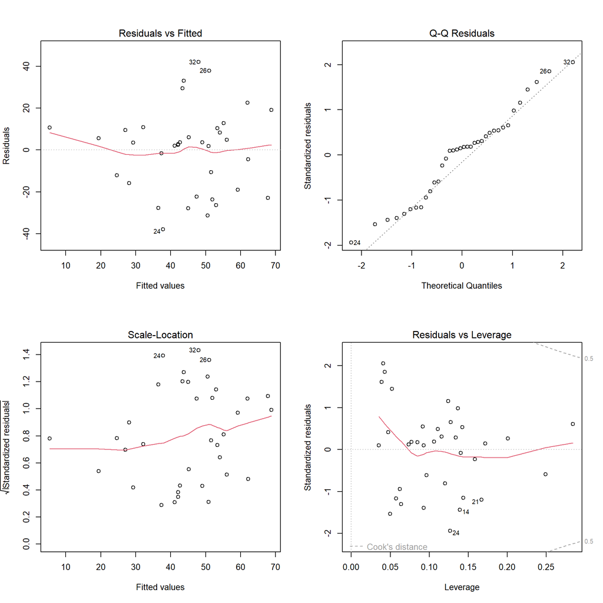

In summing up this section, the findings from the regression analysis do not support the initial causal hypothesis (H1) that higher political stability leads to increased public trust in the police. In the bivariate analysis, the relationship between political stability and trust was weakly negative and lacked statistical significance. Upon controlling for the two confounding variables such as rule of law and GDP per capita, the coefficient for political stability became even more negative, highlighting that the initial association was likely spurious and driven by other institutional and economic factors. In the comprehensive model, the residual association between political stability and trust remains negative and statistically insignificant, indicating no evidence of a genuine relationship. Given that the p-values associated with political stability consistently exceed conventional significance thresholds (p > 0.10 and p > 0.05), we cannot reject the null hypothesis at the 90% or 95% confidence levels. Consequently, the results do not support a meaningful causal influence of political stability on public trust in the police.

# Conclusion

This research explored the proposed link between political stability and absence of violence or terrorism and public trust in the police in African nations, indicating that although political stability is typically thought to promote institutional legitimacy, its actual connection with trust in law enforcement is weak and ultimately turns negative when critical confounding factors like Rule of Law and GDP per capita are accounted for. In all the models that were tested the Rule of Law estimate consistently appeared as a strong and statistically significant predictor of trust, highlighting the significance of fairness, transparency, and legal integrity beyond just political order in influencing the public institutional trust. These findings from the broad report underscore the ongoing difficulty in social science of converting abstract theoretical ideas into quantifiable variables since operationalisation frequently does not reflect the complexity of actual phenomena, especially when cross-national data are constrained by small sample size, and diverse contexts. Therefore, although theory offers useful models for grasping institutional dynamics, empirical statistical data analysis requires more careful interpretation, which may reveal an unexpected finding against what made sense theoretically.

# Reference List

Boateng, F. D. (2012). Public Trust in the Police: Identifying factors that shape trust in the Ghanaian Police (Doctoral dissertation, Washington State University).

Fagbemi, F., & Fajingbesi, A. (2022). Political violence: why conflicts can result from sub-Saharan African socioeconomic conditions. *Journal of Business and Socio-economic Development*, 2(2), 153-164.

Gaberli, Y. C., Gaberli, Ü., & Güler, M. E. (2022). Impact of political stability and absence of violence/terrorism on tourism: A panel co-integration analysis. *Journal of Management and Economics Research*, 20(4), 387-400.

Goldsmith, A. (2005). Police reform and the problem of trust. *Theoretical criminology*, 9(4), 443-470.

Kaufmann, D., & Kraay, A. (2024). The worldwide governance indicators.

Morris, C. (2015). An international study on public confidence in police. *Police practice and research*, 16(5), 416-430.

# Appendix

#### *Appendix 1: The Report Complete Data with columns CountryCode, Country, Year, PS.est, PTP.est, RL.est, GDP.est($), LogGDP.est*

Data Table: The Key varibales and controls + LogGDP

| Code | Country | Year | PS.est | PTP.est | RL.est | GDP.est ($) | LogGDP.est |
| --- | --- | --- | --- | --- | --- | --- | --- |
| AGO | Angola | 2022 | -0.630 | 25.0 | -1.022 | 7397.486 | 8.908895 |
| BEN | Benin | 2022 | -0.343 | 76.7 | -0.596 | 3588.335 | 8.185444 |
| BFA | Burkina Faso | 2022 | -1.815 | 84.6 | -0.612 | 2466.053 | 7.810374 |
| BWA | Botswana | 2022 | 1.074 | 44.9 | 0.459 | 18648.136 | 9.833502 |
| CIV | Cote d’Ivoire | 2022 | -0.587 | 43.1 | -0.474 | 6261.533 | 8.742180 |
| CMR | Cameroon | 2022 | -1.380 | 43.0 | -1.039 | 4843.650 | 8.485424 |
| CPV | Cabo Verde | 2022 | 0.927 | 63.7 | 0.399 | 8850.107 | 9.088185 |
| ETH | Ethiopia | 2022 | -2.071 | 57.7 | -0.636 | 2655.578 | 7.884418 |
| GAB | Gabon | 2022 | 0.060 | 16.2 | -0.824 | 18662.050 | 9.834247 |
| GHA | Ghana | 2022 | -0.195 | 19.3 | -0.080 | 6729.274 | 8.814223 |
| GIN | Guinea | 2022 | -0.839 | 32.8 | -1.098 | 3792.011 | 8.240652 |
| GMB | Gambia | 2022 | 0.044 | 52.7 | -0.455 | 2863.180 | 7.959688 |
| KEN | Kenya | 2022 | -0.947 | 28.3 | -0.318 | 5491.694 | 8.610992 |
| LBR | Liberia | 2022 | -0.267 | 17.2 | -0.916 | 1578.998 | 7.364546 |
| LSO | Lesotho | 2022 | -0.293 | 26.6 | -0.473 | 2577.545 | 7.854593 |
| MAR | Morocco | 2022 | -0.362 | 72.8 | -0.207 | 8666.079 | 9.067172 |
| MDG | Madagascar | 2022 | -0.481 | 51.2 | -0.950 | 1622.611 | 7.391792 |
| MLI | Mali | 2022 | -2.561 | 61.0 | -0.982 | 2357.190 | 7.765226 |
| MOZ | Mozambique | 2022 | -1.266 | 52.8 | -1.025 | 1476.666 | 7.297542 |
| MUS | Mauritius | 2022 | 0.830 | 40.9 | 0.796 | 24831.373 | 10.119863 |
| MWI | Malawi | 2022 | -0.158 | 45.0 | -0.222 | 1659.959 | 7.414548 |
| NAM | Namibia | 2022 | 0.560 | 68.0 | 0.415 | 9948.465 | 9.205174 |
| NER | Niger | 2022 | -1.464 | 87.9 | -0.498 | 1717.519 | 7.448636 |
| NGA | Nigeria | 2022 | -1.779 | 0.0 | -0.914 | 5552.838 | 8.622064 |
| SDN | Sudan | 2022 | -2.077 | 35.8 | -1.260 | 3132.077 | 8.049452 |
| SEN | Senegal | 2022 | -0.158 | 88.9 | -0.269 | 4227.733 | 8.349421 |
| SLE | Sierra Leone | 2022 | -0.095 | 8.8 | -0.831 | 2934.030 | 7.984132 |
| STP | Sao Tome and Principe | 2022 | 0.460 | 12.3 | -0.634 | 5632.139 | 8.636245 |
| SWZ | Eswatini | 2022 | -0.210 | 12.5 | -0.645 | 9740.065 | 9.184003 |
| TGO | Togo | 2022 | -0.788 | 62.4 | -0.550 | 2662.259 | 7.886930 |
| TUN | Tunisia | 2022 | -0.595 | 46.3 | -0.113 | 12632.039 | 9.443992 |
| TZA | Tanzania | 2022 | -0.260 | 89.9 | -0.462 | 3546.981 | 8.173852 |
| UGA | Uganda | 2022 | -0.711 | 40.2 | -0.374 | 2724.906 | 7.910189 |
| ZAF | South Africa | 2022 | -0.681 | 25.1 | 0.041 | 13777.193 | 9.530770 |
| ZMB | Zambia | 2022 | 0.161 | 44.6 | -0.517 | 3585.124 | 8.184548 |
| ZWE | Zimbabwe | 2022 | -0.895 | 36.6 | -1.237 | 3323.122 | 8.108660 |